# Making plots with `ggplot2`: Barplots and Scatterplots

#### Inside `aes()` or outside `aes()`?

What is the difference between these two graphs?

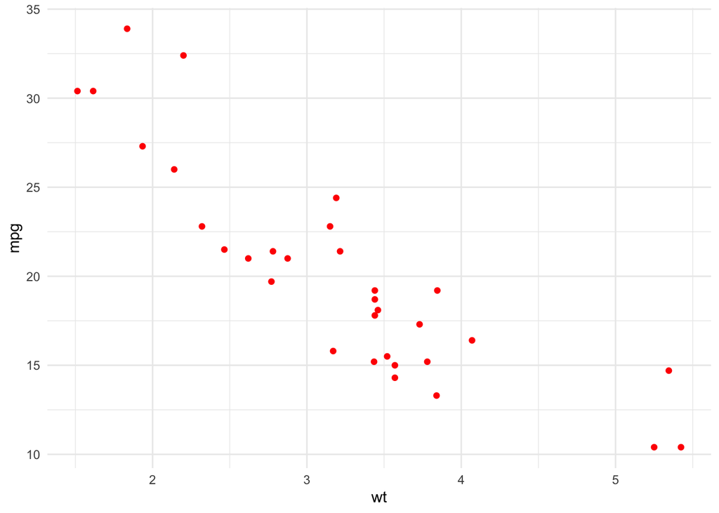

```r
ggplot(mtcars, aes(x=wt, y=mpg)) +
  geom_point(color="red") +
  theme_minimal()
```

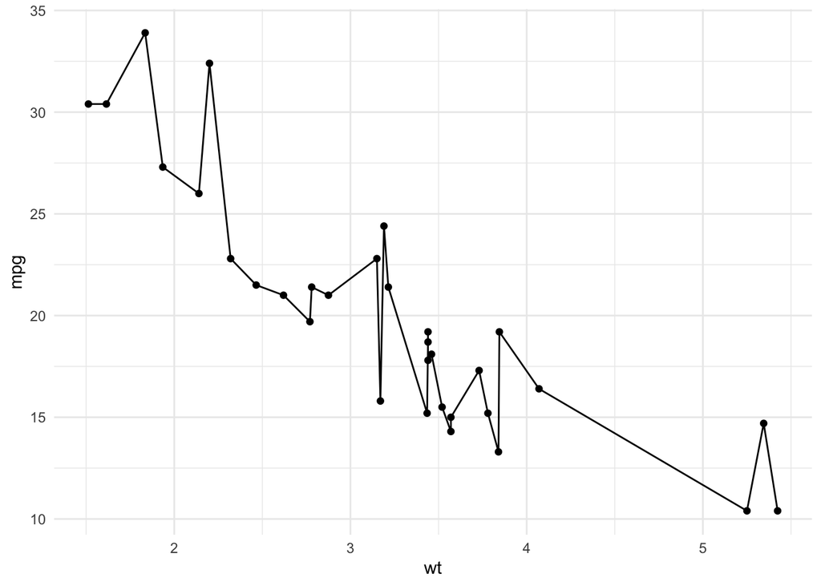

```r
# global variables
ggplot(mtcars, aes(x=wt, y=mpg)) +
  geom_point() +
  geom_line() +
  theme_minimal()
```

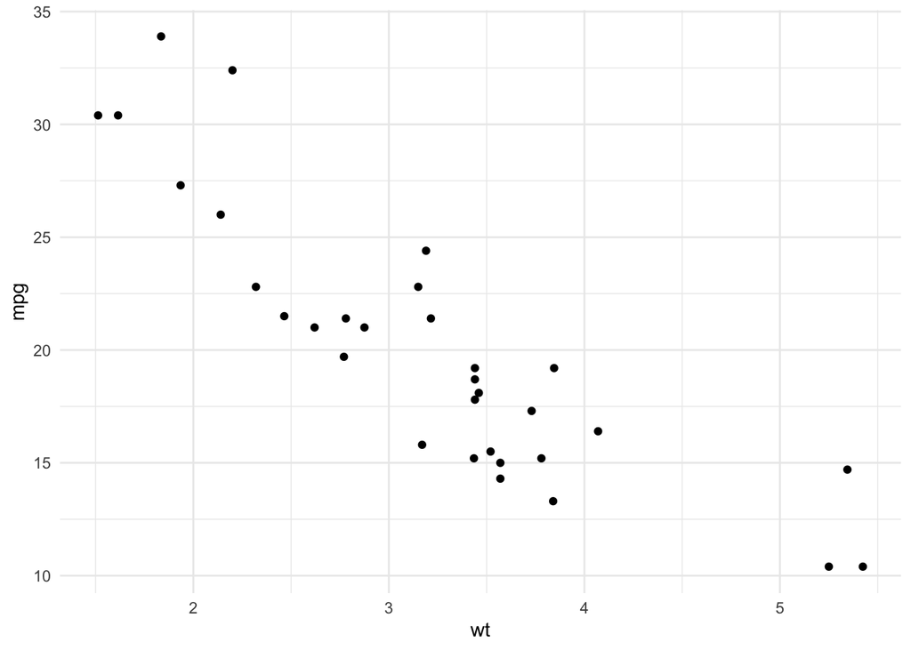

```r
#local variables
ggplot() +
  geom_point(data=mtcars, aes(x=wt, y=mpg)) +
  geom_line() +
  theme_minimal()
```

**Tip**

- If the thing you are trying to change (color, shape, size, etc.) depends on a variable, you should put in *inside* the aesthetics
- If the thing you are trying to change (color, shape, size, etc.) should happen for all things, you should not put it inside the aesthetics.

### Customizing Colors in Aesthetics

We are going to take a look at three different ways to control colors for both discrete and continuous variables. First we are going to take a look at how to define colors for a discrete variable using the `am_factor` variable that we created above which takes on the value of either 0 or 1.

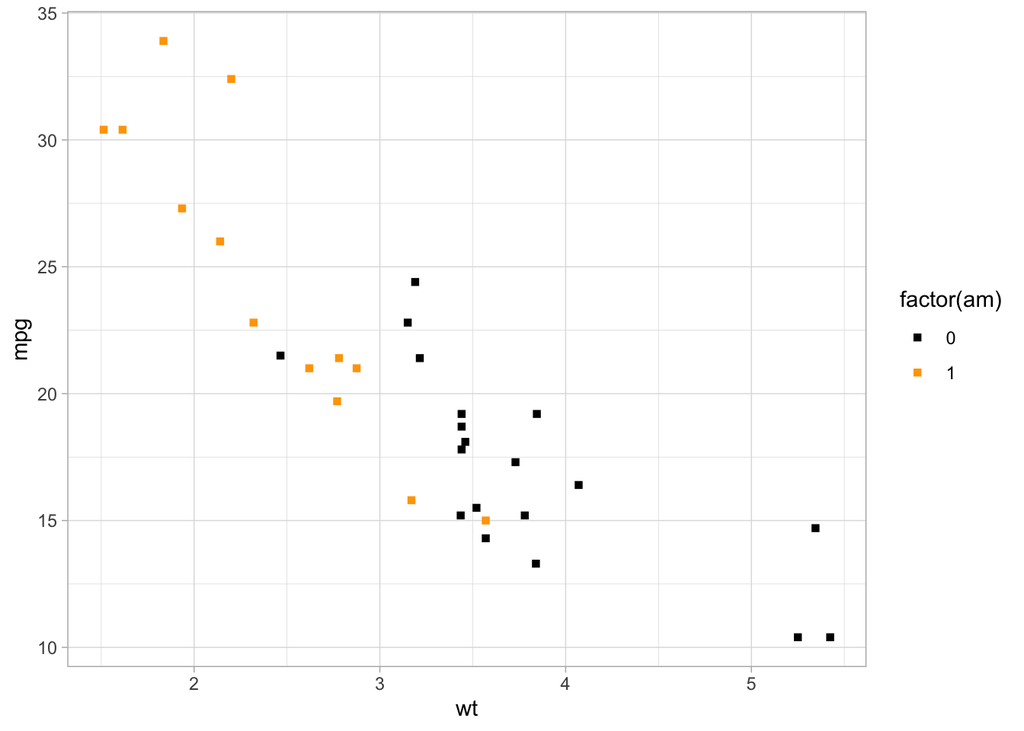

```r
# color in aesthetics

# for discrete variables
# ggplot(mtcars, aes(x=wt, y=mpg)) +
#   geom_point(aes(color=am_factor)) +
#   scale_color_manual(values=c("black", "orange"))

mtcars |>
ggplot() +
  geom_point(aes(x=wt, y=mpg, color=factor(am)),
             shape=15) +
  scale_color_manual(values=c("black", "orange")) +
  theme_light()
```

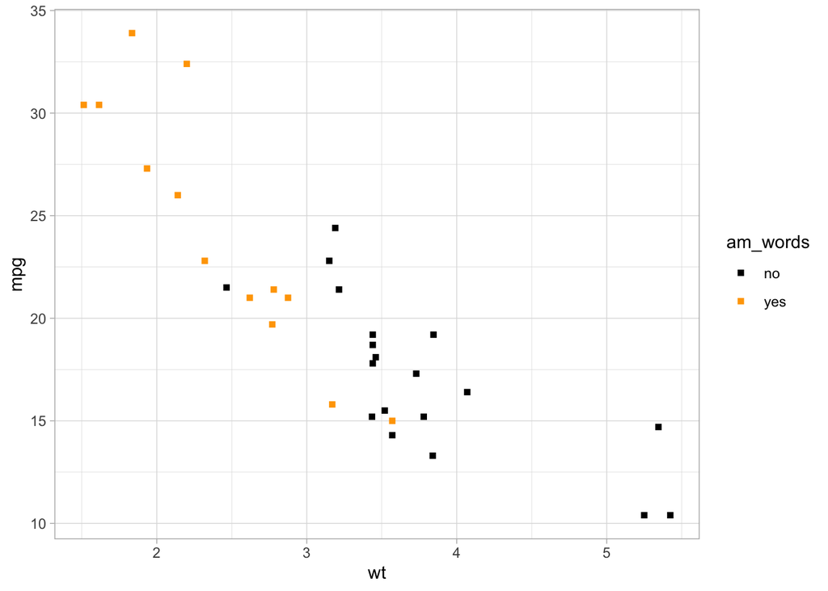

```r
mtcars |>
  mutate(am_words = case_when(am==0 ~ "no",
                              am==1 ~ "yes")) |>
ggplot() +
  geom_point(aes(x=wt, y=mpg, color=am_words),
             shape=15) +
  scale_color_manual(values=c("black", "orange")) +
  theme_light()
```

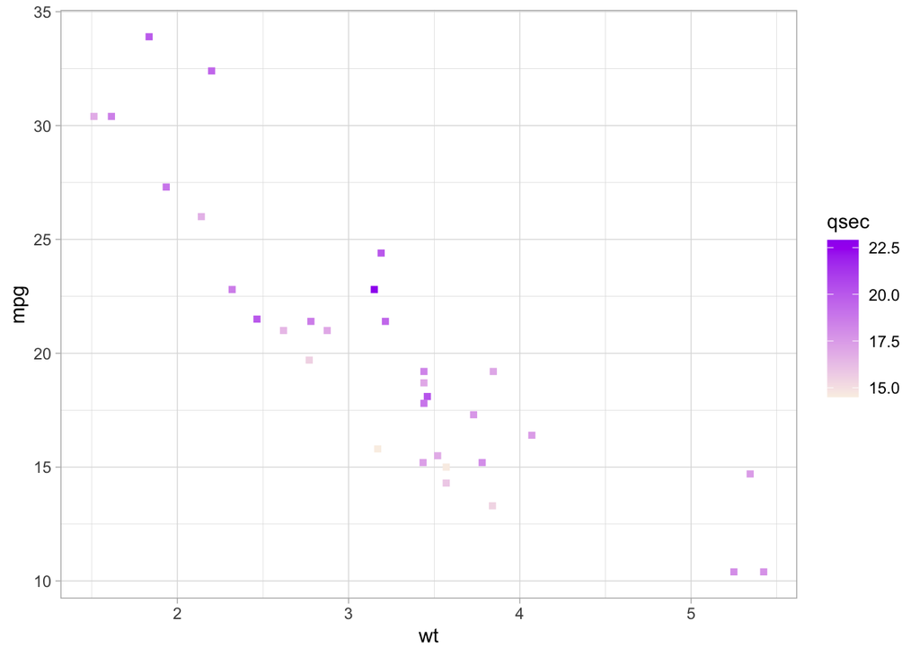

```r
# for continuous variables
# without loading in new library
# scale_color_gradient(high=, low=)
# scale_color_gradient(low  = "lightblue",high = "darkblue")
# what colors are available to you? How do you get them/name them?

mtcars |>
ggplot() +
  geom_point(aes(x=wt, y=mpg, color=qsec),
             shape=15) +
  scale_color_gradient(high="purple", low="linen") +
  theme_light()
```

There are lots of ways to control the colors and palette and we will get into how to operate more of those controls in a few classes.

**Tip**

- Use `scale_color_manual()` when assigning colors to categorical variables.
- Use `scale_color_gradient()` when assigning colors to continuous variables.